# Aula 2 - Introdução à Econometria

Autor

João Ricardo F. de Lima

Data de Publicação

25 de agosto de 2026

# Modelos de Regressão Simples

## Definição do Modelo de Regressão Simples

O modelo de regressão simples pode ser usado para estudar a relação entre duas variáveis. Em outras palavras, quando se pretender analisar como “y” varia quando “x” mudar;

Considere duas variáveis “y” e “x” que representam alguma população. A equação abaixo relaciona as duas variáveis:

$$y=\beta_0+\beta_1x+u$$

A equação acima é válida para a população de interesse e chamada de **modelo de regressão linear simples**. Pode ser também chamada de regressão bivariada ou de duas variáveis.

Quando relacionadas como acima, as variáveis *x e* y* podem ser denominadas de diversas formas:

Tabela 1: Terminologia para a regressão simples:

| Y | X |
| --- | --- |
| Variável Dependente | Variável Independente |
| Variável Explicada | Variável Explicativa |
| Variável de Resposta | Variável de Controle |
| Variável Prevista | Variável Previsora |
| Regressando | Regressor |

O termo covariável também pode ser usado para x. O mais comum é variável dependente e independente.

Se os outros fatores são fixos, sua variação é zero, ou seja, $\Delta u=0$. Assim, x tem um efeito linear sobre y:

$$\Delta y=\beta_1 \Delta x \quad se \quad \Delta u=0$$

A variação em y é, simplesmente, $\beta_1$ multiplicado pela variação em x. Isso significa que $\beta_1$ é o **parâmetro de inclinação** da relação entre y e x, mantendo fixos os fatores em u;

O **parâmetro de intercepto** $\beta_0$ é chamado de constante do modelo.

O coeficiente de inclinação mede a taxa (parcial) da mudança no valor médio de y para uma mudança de uma unidade no valor da variável independente, tudo o mais constante;

O termo de erro **u** representa todas aquelas variáveis que não podem estar explícitas no modelo por razões diversas. Contudo, se assume que a influência destas sobre o regressando é insignificante;

Pode-se entender o termo de erro como os fatores não observados que afetam y.

## Hipóteses do Modelo Clássico de Regressão Linear

Em relação ao termo de erro, é necessário fazer uma hipótese que restrinja a relação dele com a variável independente (x);

Como u e x são variáveis aleatórias, pode-se definir a distribuição condicional de u dado qualquer valor de x. A hipótese para se estimar um modelo de regressão com betas confiáveis é

$$E(u|x)=E(u)=0$$

O que está indicado na equação acima é que o valor médio de u é o mesmo para qualquer valor de x e igual a sua média aritmética. Em outras palavras, diz que u é **média-independente** de x: o valor esperado de u não muda conforme x varia.

Considerando o valor esperado da equação de Y em função de X e usando $E(u|x)=0$, se obtém:

$$E(y|x)=\beta_0+\beta_1x$$

A equação dada acima mostra que a **função de regressão populacional (FRP)**, $E(y|x)$, é uma função linear de x;

A linearidade significa que o aumento de uma unidade em x faz com que o valor esperado de y varie segundo a magnitude de $\beta_1$;

Para qualquer valor dado de x, a distribuição de y está centrada ao redor de $E(y|x)$.

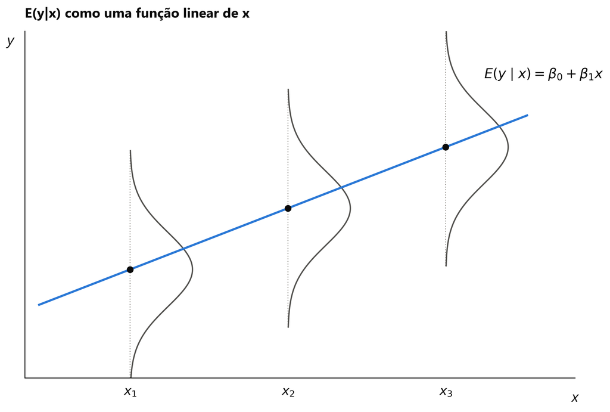

Modelo Clássico de Regressão Linear

Fonte: elaboração própria, com base em WOOLDRIDGE, 2017

## Derivação das estimativas de Mínimos Quadrados Ordinários (MQO)

Para estimar o Modelo de Regressão Linear, ou seja, encontrar os parâmetros $\beta_0$ e $\beta_1$ da primeira equação acima o método mais usado é o dos Mínimos Quadrados Ordinários (MQO), pois é intuitivamente e matematicamente mais simples;

Dado que um Modelo de Regressão:

$$Y=\widehat{\beta}_0+\widehat{\beta}_1X+\widehat{u}$$

pode ser definido também como:

$$\widehat{Y}=\widehat{\beta}_0+\widehat{\beta}_1X$$

em que o “chápeu” sobre Y, os betas e u enfatiza que os valores são estimativas.

Pode-se reescrever de forma que:

$$Y=\widehat{Y}+\widehat{u}$$

ou ainda:

$$\widehat{u}=Y-\widehat{Y}$$

então, um método bom para se obter as estimativas dos $\beta$s seria fazer com que a soma de todos os erros fosse a menor possível;

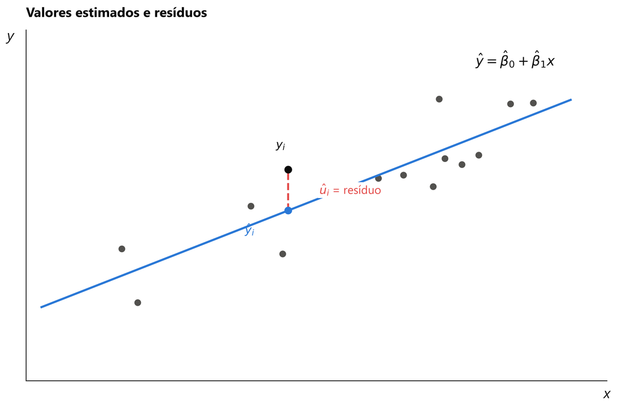

Modelo Clássico de Regressão Linear

Fonte: elaboração própria, com base em WOOLDRIDGE, 2017

Por questões teóricas, o método dos Mínimos Quadrados Ordinários (MQO) minimiza a soma dos erros ao quadrado, dando peso diferente às observações cujo valor estimado esteja mais próximo ou mais distante do valor observado ($Y$);

Assim, o que se precisa é minimizar uma função conhecida como Soma de Quadrados dos Resíduos (SQR):

$$min \sum\widehat{u}^2=\sum(Y-\widehat{\beta}_0-\widehat{\beta}_1X)^2$$

$$\frac{\partial\sum u^2}{\partial \beta_0}=2\sum(Y-\hat{\beta_0}-\hat{\beta_1}X)(-1)=-2\sum(Y-\hat{\beta_0}-\hat{\beta_1}X)$$

$$\frac{\partial\sum u^2}{\partial \beta_1}=2\sum(Y-\hat{\beta_0}-\hat{\beta_1}X)(-X)=-2\sum(Y-\hat{\beta_0}-\hat{\beta_1}X)(X)$$

Igualando as derivadas a zero, tem-se

$$-2\sum(Y-\hat{\beta_0}-\hat{\beta_1}X)=0$$

$$-2\sum(Y-\hat{\beta_0}-\hat{\beta_1}X)(X)=0$$

Se dividir tudo por -2N, tem-se

$$\frac{\sum(Y-\hat{\beta_0}-\hat{\beta_1}X)}{N}=0$$

$$\frac{\sum(Y-\hat{\beta_0}-\hat{\beta_1}X)(X)}{N}=0$$

Usando o operador do somatório tem-se:

$$\overline{Y}=\hat{\beta_0}+\hat{\beta_1}\overline{X}$$

$$\hat{\beta_0}=\overline{Y}-\hat{\beta_1}\overline{X}$$

Uma vez que se tenha $\hat{\beta_1}$, dados os valores das médias de Y e X se obtém o valor de $\hat{\beta_0}$.

Considerando a outra equação, mas suprimindo o N, que não afeta a solução, se pode obter:

$$\sum(Y-(\overline{Y}-\hat{\beta_1}\overline{X})-\hat{\beta_1}X)(X)=0$$

Expandindo os termos dentro do somatório:

$$\sum(X)(Y-\overline{Y})+\hat{\beta_1}\sum(X)(\overline{X}-X)=0$$

Como $\hat{\beta_1}$ é uma constante e colocando em evidência:

$$\sum(X)(Y-\overline{Y})=\hat{\beta_1}\sum(X)(X-\overline{X})$$

Das propriedades do somatório, se tem que:

$$\sum(X)(Y-\overline{Y})=\sum(X-\overline{X})(Y-\overline{Y})$$

$$\sum(X)(X-\overline{X})=\sum(X-\overline{X})^2$$

Então, desde que $\sum(X-\overline{X})^2>0$, a inclinação estimada é

$$\hat{\beta_1}=\frac{\sum(X-\overline{X})(Y-\overline{Y})}{\sum(X-\overline{X})^2}$$

$$\hat{\beta_1}=\frac{\sum xy}{\sum x^2}$$

com $x=X-\overline{X}$ e $y=Y-\overline{Y}$.

A equação dada em acima é a covariância amostral de x e y dividida pela variância amostral de x. Podemos reescrever a forma de encontrar o $\hat{\beta}_1$ multiplicando e dividindo por $\hat{\sigma}_y$:

$$\hat{\beta_1}=\frac{cov(xy)}{\hat{\sigma}_x \hat{\sigma}_y}\frac{\hat{\sigma}_y}{\hat{\sigma}_x}$$

$$\hat{\beta_1}=\hat{\rho}_{xy}\frac{\hat{\sigma}_y}{\hat{\sigma}_x}$$

Em que $\hat{\rho}_{xy}$ é a correlação amostral entre x e y; e $\hat{\sigma}_y$ e $\hat{\sigma}_x$ são os desvios padrões amostrais. Se a correlação de x e y for positiva, $\hat\beta_1>0$ e se for negativa, $\hat\beta_1<0$.

Uma vez determinados os estimadores de intercepto e inclinação de MQO (Mínimos Quadrados Ordinários), se constrói a **reta de regressão de MQO**:

$$\hat{y}=\hat{\beta}_{0}+\hat{\beta}_{1}x$$

A função dada em acima é chamada de função de regressão amostral (FRA), pois ela é uma versão estimada da função de regressão populacional $E(y|x)=\beta_{0}+\beta_1x$.

Como a FRA é obtida para determinada amostra de dados, uma amostra diferente irá gerar um intercepto e um coeficiente de inclinação diferentes.

## Exemplo da Regressão Simples

Com os dados de CEOSAL1, estimar a regressão entre salario anual em milhares de dólares (salary) de diretores executivos e retorno médio sobre o patrimônio líquido (roe), que é dado como uma % do patrimônio líquido.

## Exemplo no R

### Diretório e Carregamento dos pacotes

```r
#Verificando o diretorio que o R está direcionado
#getwd()

#Direcionado o R para o Diretorio a ser trabalhado
#setwd('/Users/jricardofl/Dropbox/tempecon/Facape/econometria1')

#Limpa o Ambiente Global
rm(list=ls())

#Pode usar dados de outros softwares
library(wooldridge)
library(ggplot2)
library(dplyr)
library(rstatix)
```

### Entrada dos dados

```r
#Carregar dados no computador
data('ceosal1')

#Observar a estrutura dos dados
glimpse(ceosal1)
```

```
Rows: 209
Columns: 12
$ salary   <int> 1095, 1001, 1122, 578, 1368, 1145, 1078, 1094, 1237, 833, 567…
$ pcsalary <int> 20, 32, 9, -9, 7, 5, 10, 7, 16, 5, 7, -3, -9, 9, 49, 4, 12, 9…
$ sales    <dbl> 27595.0, 9958.0, 6125.9, 16246.0, 21783.2, 6021.4, 2266.7, 29…
$ roe      <dbl> 14.1, 10.9, 23.5, 5.9, 13.8, 20.0, 16.4, 16.3, 10.5, 26.3, 25…
$ pcroe    <dbl> 106.4, -30.6, -16.3, -25.7, -3.0, 1.0, -5.9, -1.6, -70.2, -23…
$ ros      <int> 191, 13, 14, -21, 56, 55, 62, 44, 37, 37, 109, -10, 41, 44, 6…
$ indus    <int> 1, 1, 1, 1, 1, 1, 1, 1, 1, 1, 1, 1, 1, 1, 1, 1, 1, 1, 1, 1, 1…
$ finance  <int> 0, 0, 0, 0, 0, 0, 0, 0, 0, 0, 0, 0, 0, 0, 0, 0, 0, 0, 0, 0, 0…
$ consprod <int> 0, 0, 0, 0, 0, 0, 0, 0, 0, 0, 0, 0, 0, 0, 0, 0, 0, 0, 0, 0, 0…
$ utility  <int> 0, 0, 0, 0, 0, 0, 0, 0, 0, 0, 0, 0, 0, 0, 0, 0, 0, 0, 0, 0, 0…
$ lsalary  <dbl> 6.998509, 6.908755, 7.022868, 6.359574, 7.221105, 7.043160, 6…
$ lsales   <dbl> 10.225389, 9.206132, 8.720281, 9.695602, 9.988894, 8.703075, …
```

```r
tail(ceosal1)
```

|  | salary | pcsalary | sales | roe | pcroe | ros | indus | finance | consprod | utility | lsalary | lsales |
| --- | --- | --- | --- | --- | --- | --- | --- | --- | --- | --- | --- | --- |
| 204 | 808 | -16 | 7198.5 | 14.7 | 7.4 | 49 | 0 | 0 | 0 | 1 | 6.694562 | 8.881628 |
| 205 | 930 | 10 | 1509.1 | 9.0 | 20.5 | 131 | 0 | 0 | 0 | 1 | 6.835185 | 7.319269 |
| 206 | 525 | 3 | 1097.1 | 15.5 | 20.1 | 72 | 0 | 0 | 0 | 1 | 6.263398 | 7.000426 |
| 207 | 658 | 32 | 4542.6 | 12.1 | -7.8 | 68 | 0 | 0 | 0 | 1 | 6.489205 | 8.421255 |
| 208 | 555 | 6 | 2023.0 | 13.7 | -14.6 | 60 | 0 | 0 | 0 | 1 | 6.318968 | 7.612337 |
| 209 | 626 | 0 | 1442.5 | 14.4 | -10.2 | 62 | 0 | 0 | 0 | 1 | 6.439351 | 7.274133 |

### Estatística Descritiva

A primeira análise é sobre as estatísticas descritivas das duas variáveis.

```r
attach(ceosal1)
#Estatistica Descritiva dos Dados
summary(salary)
```

```
   Min. 1st Qu.  Median    Mean 3rd Qu.    Max.
    223     736    1039    1281    1407   14822
```

```r
summary(roe)
```

```
   Min. 1st Qu.  Median    Mean 3rd Qu.    Max.
   0.50   12.40   15.50   17.18   20.00   56.30
```

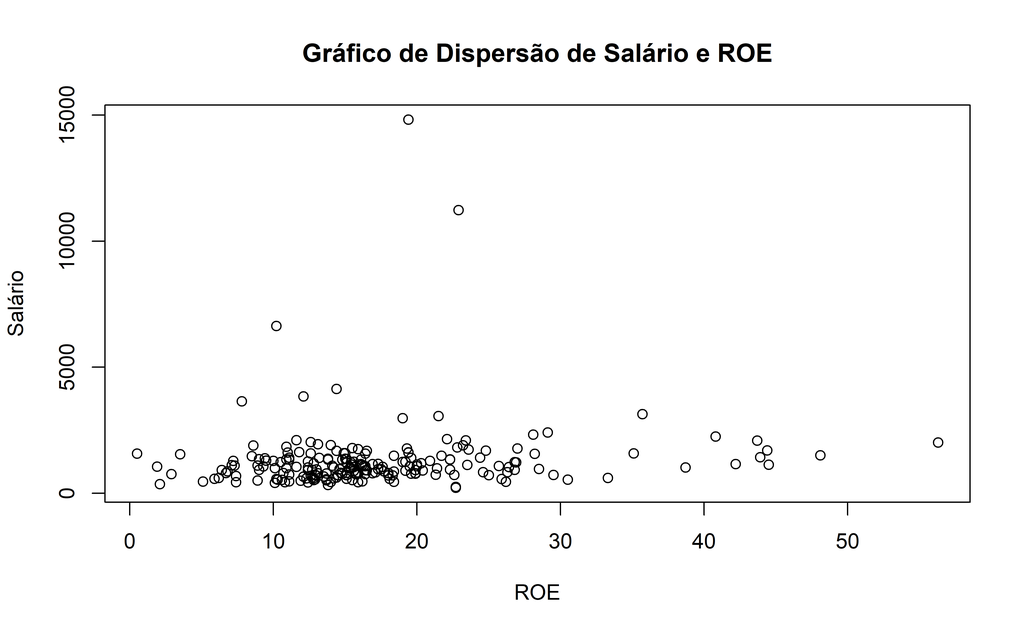

```r
# Gráfico de Dispersão dos dados

plot(salary ~ roe,
     data = ceosal1,
     main = "Gráfico de Dispersão de Salário e ROE",
     ylab = "Salário",
     xlab = "ROE")
```

```r
cor(salary, roe)
```

```
[1] 0.1148417
```

### Estimação do Modelo

A tarefa que enfrentamos agora é encontrar uma linha que melhor se ajuste aos dados. É claro que seria possível simplesmente ficar com a inspeção gráfica e a análise de correlação e, em seguida, selecionar a melhor linha de ajuste observando.

No entanto, isso seria bastante subjetivo: diferentes observadores traçariam diferentes linhas de regressão. Por conta disso, estamos interessados em técnicas menos arbitrárias. Tal técnica é dada pela estimativa de mínimos quadrados ordinários (MQO).

Em seguida, a análise de regressão simples com o cálculo dos betas de diversas formas:

```r
#Estimar a regressao com intercepto

# computa beta_1_chapéu
beta_1 <- sum((roe - mean(roe)) * (salary - mean(salary))) / sum((roe - mean(roe))^2)

# computa beta_0_chapéu
beta_0 <- mean(salary) - beta_1 * mean(roe)

# mostra os resultados no Console
beta_1
```

```
[1] 18.50119
```

```r
beta_0
```

```
[1] 963.1913
```

```r
# Outra forma
regressao1 <- lm(salary ~ roe, data=ceosal1)

#Resultados da Regressao
summary(regressao1)
```

```
Call:
lm(formula = salary ~ roe, data = ceosal1)

Residuals:
    Min      1Q  Median      3Q     Max
-1160.2  -526.0  -254.0   138.8 13499.9

Coefficients:
            Estimate Std. Error t value Pr(>|t|)
(Intercept)   963.19     213.24   4.517 1.05e-05 ***
roe            18.50      11.12   1.663   0.0978 .
---
Signif. codes:  0 '***' 0.001 '**' 0.01 '*' 0.05 '.' 0.1 ' ' 1

Residual standard error: 1367 on 207 degrees of freedom
Multiple R-squared:  0.01319,   Adjusted R-squared:  0.008421
F-statistic: 2.767 on 1 and 207 DF,  p-value: 0.09777
```

### Gráfico do Modelo Estimado

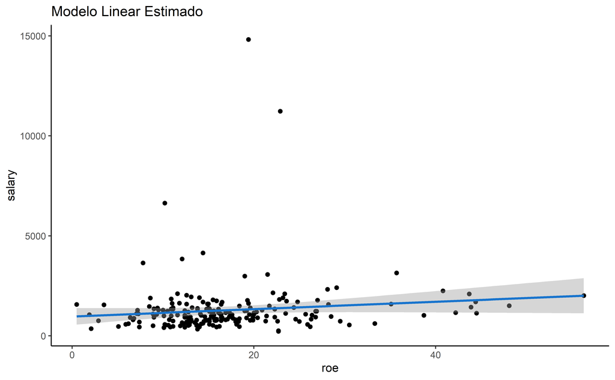

```r
g1 <- ggplot(data = ceosal1, aes(x = roe, y = salary)) +
  geom_point() +
  stat_smooth(method = "lm", col = "dodgerblue3") +
  theme(panel.background = element_rect(fill = "white"),
        axis.line.x=element_line(),
        axis.line.y=element_line()) +
  ggtitle("Modelo Linear Estimado")

g1
```

### Fazer previsão com base no modelo estimado

Com base no modelo estimado é possível fazer previsões. Se $roe=30$, quanto seria o salário estimado?

```r
predict(regressao1, data.frame(roe = 30))
```

```
       1
1518.227
```

## Exemplo no Python

```python
import wooldridge
import pandas as pd
import numpy as np
import matplotlib.pyplot as plt
import seaborn as sns
import statsmodels.formula.api as smf

#Carregar dados no computador
ceosal1 = wooldridge.data('ceosal1')

#Observar a estrutura dos dados
wooldridge.data('ceosal1', description=True)
```

```
name of dataset: ceosal1
no of variables: 12
no of observations: 209

+----------+-------------------------------+
| variable | label                         |
+----------+-------------------------------+
| salary   | 1990 salary, thousands $      |
| pcsalary | % change salary, 89-90        |
| sales    | 1990 firm sales, millions $   |
| roe      | return on equity, 88-90 avg   |
| pcroe    | % change roe, 88-90           |
| ros      | return on firm's stock, 88-90 |
| indus    | =1 if industrial firm         |
| finance  | =1 if financial firm          |
| consprod | =1 if consumer product firm   |
| utility  | =1 if transport. or utilties  |
| lsalary  | natural log of salary         |
| lsales   | natural log of sales          |
+----------+-------------------------------+

I took a random sample of data reported in the May 6, 1991 issue of
Businessweek.
```

```python
# Estatística descritiva
ceosal1.info()
```

```
<class 'pandas.core.frame.DataFrame'>
RangeIndex: 209 entries, 0 to 208
Data columns (total 12 columns):
 #   Column    Non-Null Count  Dtype
---  ------    --------------  -----
 0   salary    209 non-null    int64
 1   pcsalary  209 non-null    int64
 2   sales     209 non-null    float64
 3   roe       209 non-null    float64
 4   pcroe     209 non-null    float64
 5   ros       209 non-null    int64
 6   indus     209 non-null    int64
 7   finance   209 non-null    int64
 8   consprod  209 non-null    int64
 9   utility   209 non-null    int64
 10  lsalary   209 non-null    float64
 11  lsales    209 non-null    float64
dtypes: float64(5), int64(7)
memory usage: 19.7 KB
```

```python
ceosal1["salary"].describe()
```

```
count      209.000000
mean      1281.119617
std       1372.345308
min        223.000000
25%        736.000000
50%       1039.000000
75%       1407.000000
max      14822.000000
Name: salary, dtype: float64
```

```python
ceosal1["roe"].describe()
```

```
count    209.000000
mean      17.184211
std        8.518509
min        0.500000
25%       12.400000
50%       15.500000
75%       20.000000
max       56.299999
Name: roe, dtype: float64
```

```python
# Covariância e Correlação
ceosal1.cov()
```

```
                salary     pcsalary  ...      lsalary       lsales
salary    1.883332e+06   388.384339  ...   617.306903   269.866846
pcsalary  3.883843e+02  1064.972810  ...     0.810346    -2.156540
sales     1.749198e+06  5902.668085  ...  1694.018012  8003.649550
roe       1.342538e+03    24.278515  ...     1.005938    -1.057709
pcroe     3.830507e+03   659.791671  ...     5.929907     2.293869
ros      -3.151361e+03   306.541222  ...    -2.879214   -24.198776
indus    -4.566834e+01     0.067722  ...    -0.004278     0.028570
finance   1.410816e+01    -1.230700  ...     0.023720     0.016421
consprod  1.272972e+02     0.769530  ...     0.056578    -0.008762
utility  -9.573705e+01     0.393449  ...    -0.076020    -0.036229
lsalary   6.173069e+02     0.810346  ...     0.320780     0.263472
lsales    2.698668e+02    -2.156540  ...     0.263472     1.026494

[12 rows x 12 columns]
```

```python
ceosal1.corr()
```

```
            salary  pcsalary     sales  ...   utility   lsalary    lsales
salary    1.000000  0.008672  0.119869  ... -0.184309  0.794208  0.194092
pcsalary  0.008672  1.000000  0.017010  ...  0.031853  0.043843 -0.065224
sales     0.119869  0.017010  1.000000  ... -0.139245  0.281286  0.742921
roe       0.114842  0.087335 -0.055386  ... -0.310194  0.208499 -0.122553
pcroe     0.028710  0.207962  0.005594  ... -0.045260  0.107694  0.023288
ros      -0.033682  0.137778 -0.136088  ... -0.039299 -0.074565 -0.350330
indus    -0.071134  0.004436  0.093608  ... -0.313344 -0.016146  0.060278
finance   0.024754 -0.090806 -0.054073  ... -0.242333  0.100841  0.039025
consprod  0.204546  0.051999  0.069175  ... -0.289475  0.220285 -0.019071
utility  -0.184309  0.031853 -0.139245  ...  1.000000 -0.354615 -0.094472
lsalary   0.794208  0.043843  0.281286  ... -0.354615  1.000000  0.459148
lsales    0.194092 -0.065224  0.742921  ... -0.094472  0.459148  1.000000

[12 rows x 12 columns]
```

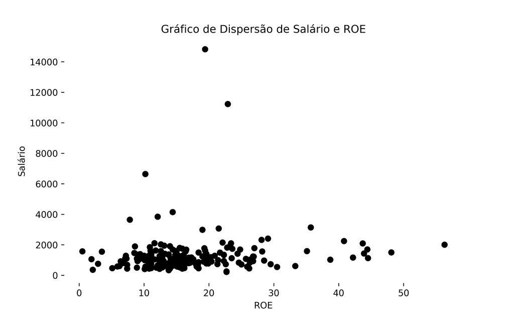

```python
# Gráfico

# plot
plt.subplots()
#plt.scatter(ceosal1["roe"], ceosal1["salary"], data=ceosal1)
plt.scatter('roe', 'salary', data = ceosal1, c = "black")
plt.xlabel('ROE')
plt.ylabel('Salário')
plt.title('Gráfico de Dispersão de Salário e ROE')
plt.box(False)
plt.show()
```

```python
# Correlação

ceosal1["salary"].corr(ceosal1["roe"], method='pearson')
```

```
np.float64(0.11484173492695979)
```

```python
# Regressão Linear Simples

reg1 = smf.ols('salary ~ roe', data = ceosal1)

#Resultado da Regressão
reg1.fit().summary()
```

OLS Regression Results

| Dep. Variable: | salary | R-squared: | 0.013 |
| --- | --- | --- | --- |
| Model: | OLS | Adj. R-squared: | 0.008 |
| Method: | Least Squares | F-statistic: | 2.767 |
| Date: | ter, 25 ago 2026 | Prob (F-statistic): | 0.0978 |
| Time: | 13:01:21 | Log-Likelihood: | -1804.5 |
| No. Observations: | 209 | AIC: | 3613. |
| Df Residuals: | 207 | BIC: | 3620. |
| Df Model: | 1 |  |  |
| Covariance Type: | nonrobust |  |  |

|  | coef | std err | t | P>\|t\| | [0.025 | 0.975] |
| --- | --- | --- | --- | --- | --- | --- |
| Intercept | 963.1913 | 213.240 | 4.517 | 0.000 | 542.790 | 1383.592 |
| roe | 18.5012 | 11.123 | 1.663 | 0.098 | -3.428 | 40.431 |

| Omnibus: | 311.096 | Durbin-Watson: | 2.105 |
| --- | --- | --- | --- |
| Prob(Omnibus): | 0.000 | Jarque-Bera (JB): | 31120.902 |
| Skew: | 6.915 | Prob(JB): | 0.00 |
| Kurtosis: | 61.158 | Cond. No. | 43.3 |

Notes:  
[1] Standard Errors assume that the covariance matrix of the errors is correctly specified.

```python
reg1.fit().params
```

```
Intercept    963.191336
roe           18.501186
dtype: float64
```

```python
# Outra Opção de Output de Resultado

result = reg1.fit()
print(result.summary())
```

```
                            OLS Regression Results
==============================================================================
Dep. Variable:                 salary   R-squared:                       0.013
Model:                            OLS   Adj. R-squared:                  0.008
Method:                 Least Squares   F-statistic:                     2.767
Date:                ter, 25 ago 2026   Prob (F-statistic):             0.0978
Time:                        13:01:21   Log-Likelihood:                -1804.5
No. Observations:                 209   AIC:                             3613.
Df Residuals:                     207   BIC:                             3620.
Df Model:                           1
Covariance Type:            nonrobust
==============================================================================
                 coef    std err          t      P>|t|      [0.025      0.975]
------------------------------------------------------------------------------
Intercept    963.1913    213.240      4.517      0.000     542.790    1383.592
roe           18.5012     11.123      1.663      0.098      -3.428      40.431
==============================================================================
Omnibus:                      311.096   Durbin-Watson:                   2.105
Prob(Omnibus):                  0.000   Jarque-Bera (JB):            31120.902
Skew:                           6.915   Prob(JB):                         0.00
Kurtosis:                      61.158   Cond. No.                         43.3
==============================================================================

Notes:
[1] Standard Errors assume that the covariance matrix of the errors is correctly specified.
```

```python
print("Parameters: ", result.params)
```

```
Parameters:  Intercept    963.191336
roe           18.501186
dtype: float64
```

```python
print(result.params.iloc[0])
```

```
963.1913364725581
```

```python
print(result.params.iloc[1])
```

```
18.50118634521493
```

```python
y_hat = result.fittedvalues
u_hat = result.resid
print(y_hat)
```

```
0      1224.058071
1      1164.854261
2      1397.969216
3      1072.348338
4      1218.507712
          ...
204    1129.702014
205    1249.959725
206    1187.055698
207    1216.657586
208    1229.608413
Length: 209, dtype: float64
```

```python
print(u_hat)
```

```
0     -129.058071
1     -163.854261
2     -275.969216
3     -494.348338
4      149.492288
          ...
204   -199.702014
205   -724.959725
206   -529.055698
207   -661.657586
208   -603.608413
Length: 209, dtype: float64
```

```python
# Gráfico da regressão
sns.set_theme()

plt.figure(figsize = (20,8))

sns.regplot(x = 'roe', y = 'salary', data = ceosal1).set(title='Modelo Linear Estimado')

# Fazer Previsão com o modelo estimado

nova_obs = pd.DataFrame({"roe": [30]})
result.predict(nova_obs)
```

```
0    1518.226927
dtype: float64
```

```python
result.get_prediction(nova_obs).summary_frame(alpha=0.05)
```

```
          mean     mean_se  ...  obs_ci_lower  obs_ci_upper
0  1518.226927  171.045889  ...  -1196.944122   4233.397976

[1 rows x 6 columns]
```

[figure not shown]